# StormData_Analysis

## Title

The goal of this project is to explore the NOAA Storm Database and answer some important questions about severe weather events.

## Synopsis

People are more concerned about the influences of severe weahter events on populatoin health and economy. So, this project investigates two related questions: the first question is “which types of events are most harmful with respect to population health?” and the second is “which types of events have the greatest economic consequences?” In the following analysis, these two questions can be answered by some tables and clear plots.

## Data processing

```r
storm_data <- read.csv(bzfile("repdata-data-StormData.csv.bz2"))
```

Event types don’t have specific format, so we need to do some preprocessing.

```r
event_type <-  tolower(storm_data$EVTYPE)
event_type <- gsub("[[:blank:][:punct:]+]","",event_type)
storm_data$EVTYPE <- event_type
```

## Results

### Which types of events are most harmful with respect to population health?

```r
event_fatality <- aggregate(FATALITIES~EVTYPE,storm_data,sum)
event_injury <- aggregate(INJURIES~EVTYPE,storm_data,sum)
```

List top 8 events that caused the most number of deaths

```r
t1 <- head(event_fatality[order(event_fatality$FATALITIES,decreasing = T),],8);t1
```

```
##            EVTYPE FATALITIES
## 693       tornado       5633
## 104 excessiveheat       1903
## 125    flashflood        978
## 215          heat        937
## 374     lightning        817
## 715      tstmwind        504
## 138         flood        470
## 480    ripcurrent        368
```

List top 8 events that caused the most number of injuries

```r
t2 <- head(event_injury[order(event_injury$INJURIES,decreasing = T),],8);t2
```

```
##            EVTYPE INJURIES
## 693       tornado    91346
## 715      tstmwind     6957
## 138         flood     6789
## 104 excessiveheat     6525
## 374     lightning     5230
## 215          heat     2100
## 351      icestorm     1975
## 125    flashflood     1777
```

### Plots of different weather event types with respect to population health

```r
library(ggplot2)
library(cowplot)
g1 <- ggplot(t1,aes(x=reorder(EVTYPE,FATALITIES),y=FATALITIES))+
  geom_bar(stat="identity",fill="seagreen")+
  labs(x="Event Type",y="Total Number of Deaths",title="Severe Weather Events w.r.t Fatalities")+
  theme(axis.text=element_text(size=8))
g2 <- ggplot(t2,aes(x=reorder(EVTYPE,INJURIES),y=INJURIES))+
  geom_bar(stat="identity",fill="seagreen")+
  labs(x="Event Type",y="Total Number of Injuries",title="Severe Weather Events w.r.t Injuries")+
  theme(axis.text=element_text(size=8))
```

The following plots show severe weather events that resulted in deaths and injuries

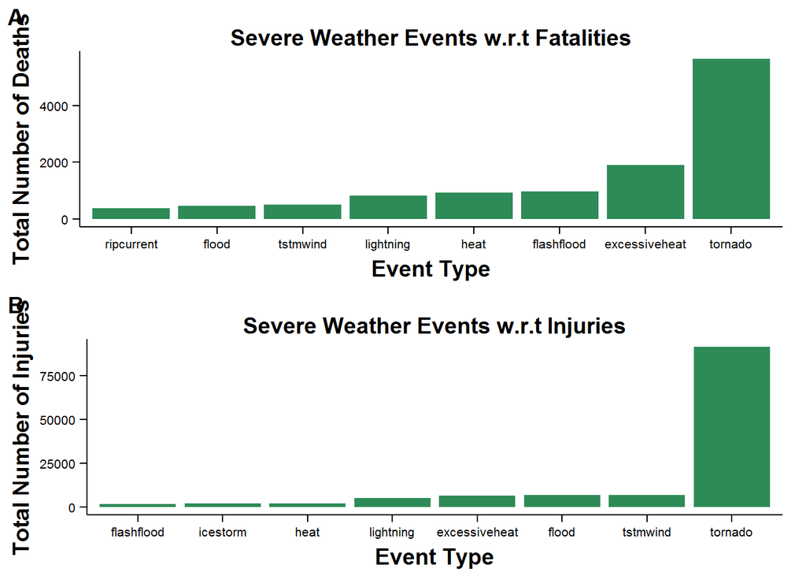

```r
plot_grid(g1, g2,labels=c("A","B"), nrow = 2)
```

### Which types of events have the greatest economic consequences?

In the raw data, economic consequences are represented by two fields, which are PROPDMG and CROPDMG. These two fields can be used to analyze the property and crop damage for each event.

```r
# function for transforming letters to exponents
expo <- function(x){
  if (x %in% c("h", "H"))
        return(2)
    else if (x %in% c("k", "K"))
        return(3)
    else if (x %in% c("m", "M"))
        return(6)
    else if (x %in% c("b", "B"))
        return(9)
    else if (!is.na(as.numeric(x)))
        return(as.numeric(x))
    else if (x %in% c('', '-', '?', '+'))
        return(0)
    else {
        stop("Invalid Value")
    }
}
```

Transform economic losses into real values

```r
prop_dmg_exp <- sapply(storm_data$PROPDMGEXP,FUN=expo)
storm_data$PROPDMG <- storm_data$PROPDMG*(10**prop_dmg_exp)
crop_dmg_exp <- sapply(storm_data$CROPDMGEXP,FUN=expo)
storm_data$CROPDMG <- storm_data$CROPDMG*(10**crop_dmg_exp)
```

```r
event_prop <- aggregate(PROPDMG~EVTYPE,storm_data,sum)
event_crop <- aggregate(CROPDMG~EVTYPE,storm_data,sum)
```

List top 6 events that caused significant property damages

```r
t3 <- head(event_prop[order(event_prop$PROPDMG,decreasing = T),]);t3
```

```
##                EVTYPE      PROPDMG
## 125        flashflood 6.820237e+13
## 657 thunderstormwinds 2.086532e+13
## 693           tornado 1.078951e+12
## 191              hail 3.157558e+11
## 374         lightning 1.729433e+11
## 138             flood 1.446577e+11
```

List top 8 events that caused significant crop damages

```r
t4 <- head(event_crop[order(event_crop$CROPDMG,decreasing = T),],8);t4
```

```
##               EVTYPE     CROPDMG
## 73           drought 13972566000
## 138            flood  5661968450
## 484       riverflood  5029459000
## 351         icestorm  5022113500
## 191             hail  3025974480
## 326        hurricane  2741910000
## 335 hurricanetyphoon  2607872800
## 125       flashflood  1421317100
```

```r
g3 <- ggplot(t3,aes(x=reorder(EVTYPE,PROPDMG),y=PROPDMG))+
  geom_bar(stat="identity",fill="seagreen")+
  labs(x="Event Type",y="Economic Losses",title="Property Damage caused by different weather events")+
  theme(axis.text=element_text(size=8))
g4 <- ggplot(t2,aes(x=reorder(EVTYPE,INJURIES),y=INJURIES))+
  geom_bar(stat="identity",fill="seagreen")+
  labs(x="Event Type",y="Economic Losses",title="Crop Damage caused by different weather events")+
  theme(axis.text=element_text(size=8))
```

[figure not shown]

```r
plot_grid(g3, g4,labels=c("A","B"), nrow = 2)
```